# Harmonized geospatial data summary

Published

November 11, 2026

## Study area

**Watershed:** Upper Tenderfoot Creek (HUC12 100301030801)  
**Area:** 105.7 km²  
**Output CRS:** EPSG:5070  
**Grid resolution:** 10 m

## Terrain and streams

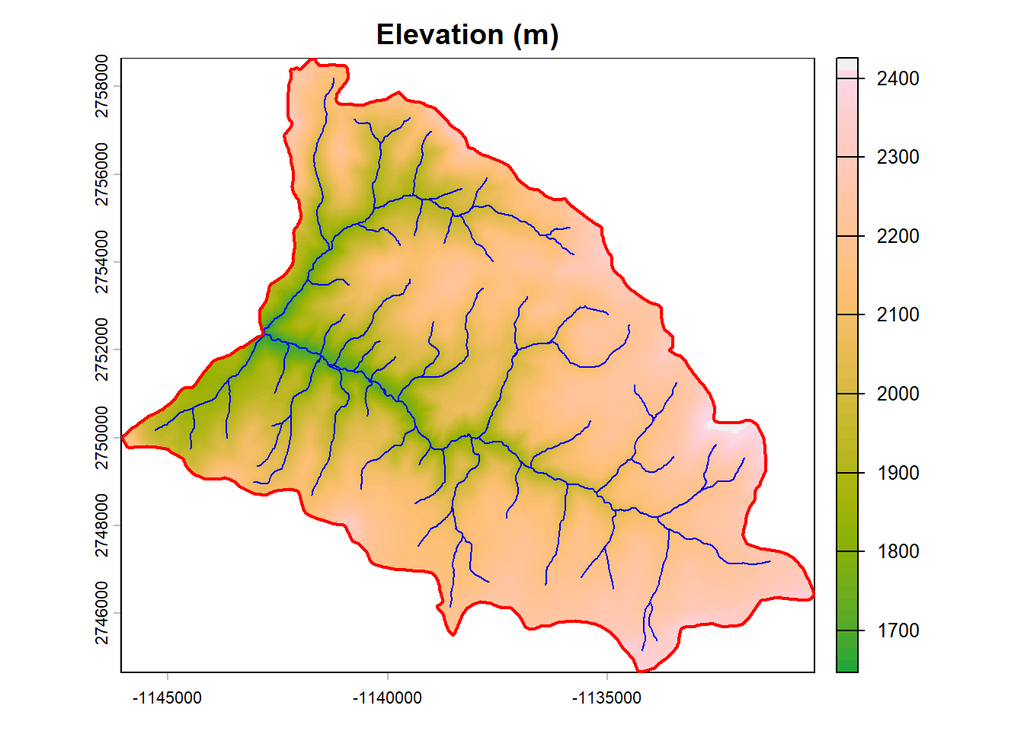

Harmonized DEM with stream network (blue) and watershed boundary (red).

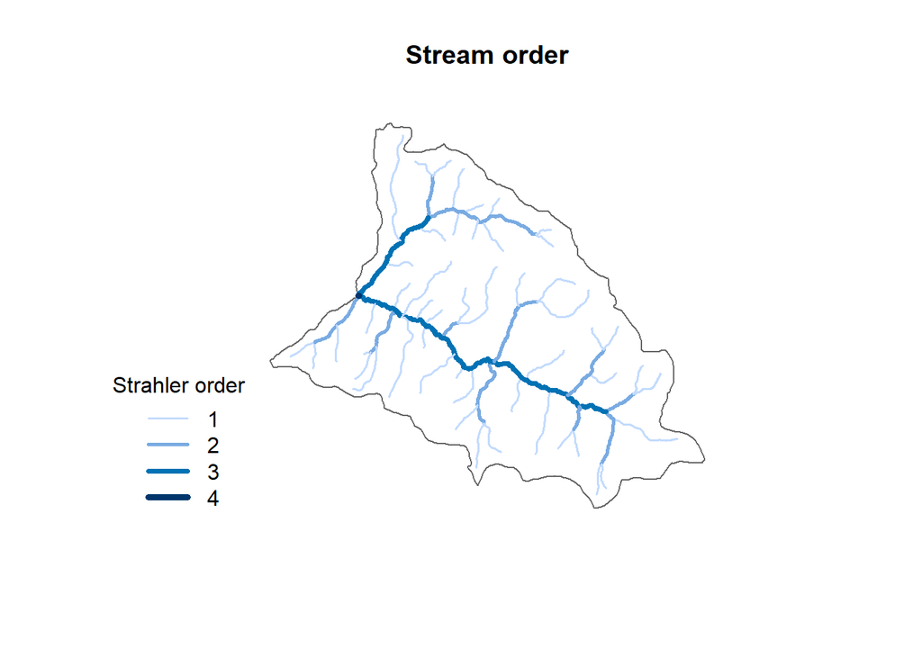

Stream network by Strahler stream order. Darker and thicker lines are higher-order (larger) streams.

## Soils

K-factors are aggregated from SSURGO components and horizons (see the decision log). Both K maps share one color scale. Soil values are uniform within each map unit polygon, so their real spatial detail is the polygon, not the 10 m grid.

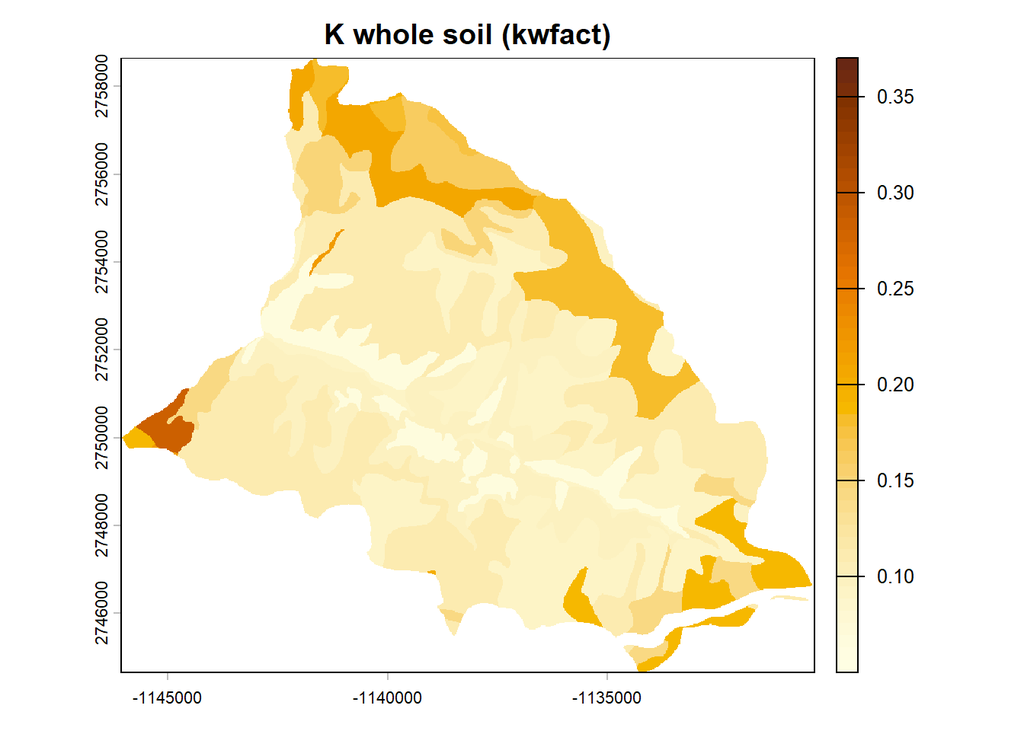

Whole-soil K-factor (kwfact), which accounts for rock fragments.

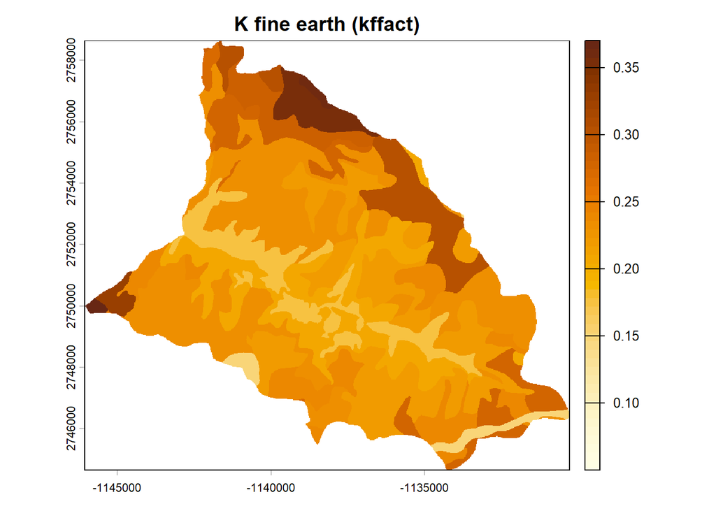

Fine-earth K-factor (kffact), which excludes rock fragments. Same color scale as the whole-soil map.

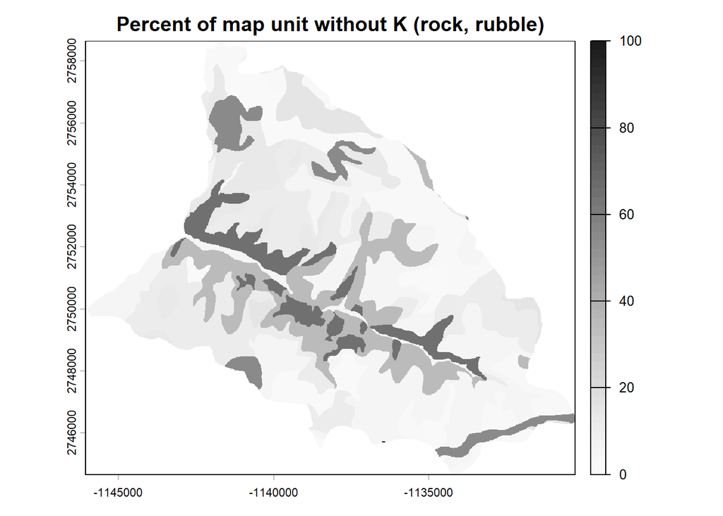

Percent of each map unit made up of components without a K-factor (rock outcrop, rubble land, pits, water).

## Precipitation

Rainfall intensity for the 2-year storm from NOAA Atlas 14 Volume 12 (partial duration series), converted from depth to intensity and resampled from about 800 m to the 10 m grid. Each map has its own color scale; intensity varies only a few percent across the watershed, so the smooth gradients show a small range.

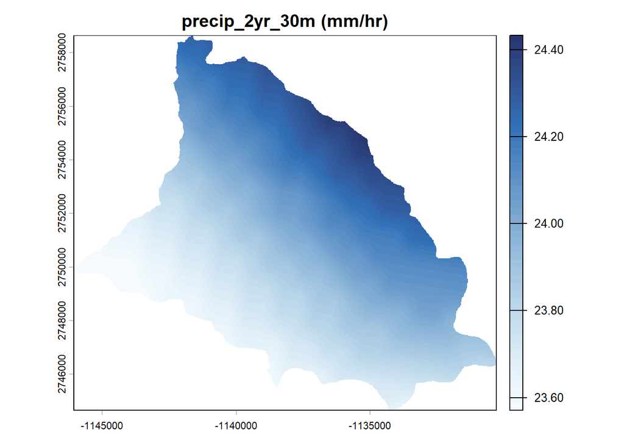

Rainfall intensity (mm/hr) by storm duration.

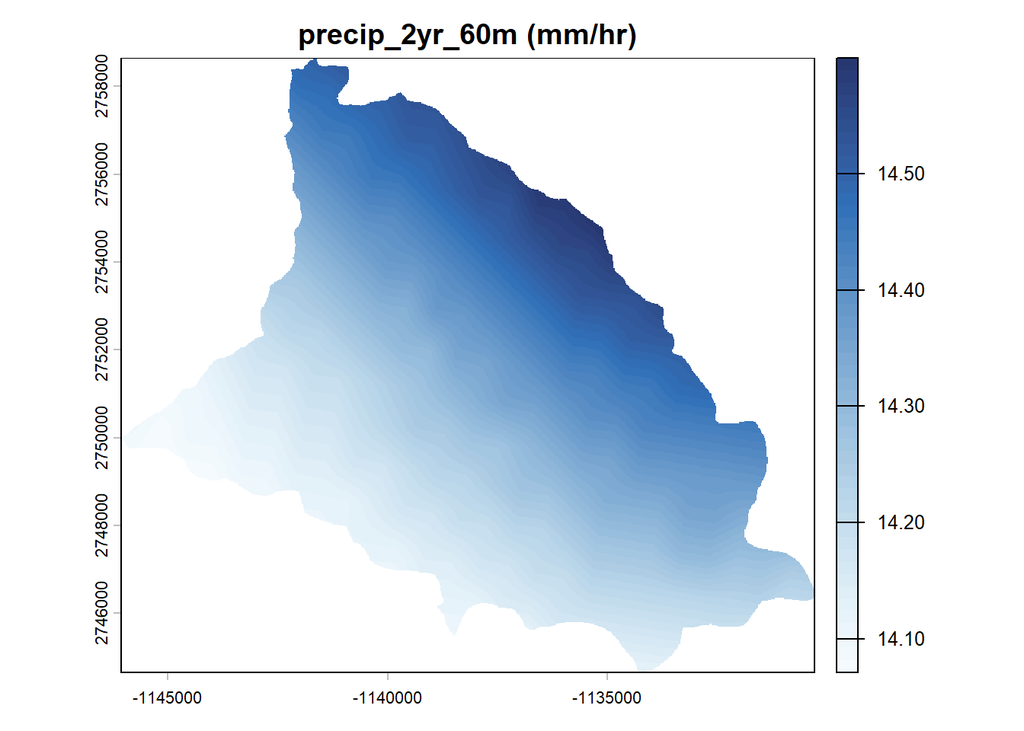

Rainfall intensity (mm/hr) by storm duration.

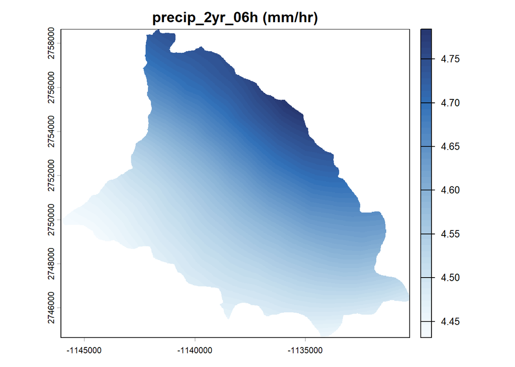

Rainfall intensity (mm/hr) by storm duration.

## Forest structure

Canopy cover and canopy height from LANDFIRE 2024, resampled from 30 m to the 10 m grid with nearest neighbor. LANDFIRE stores both as classes, so each map shows a small set of values, each representing a range.

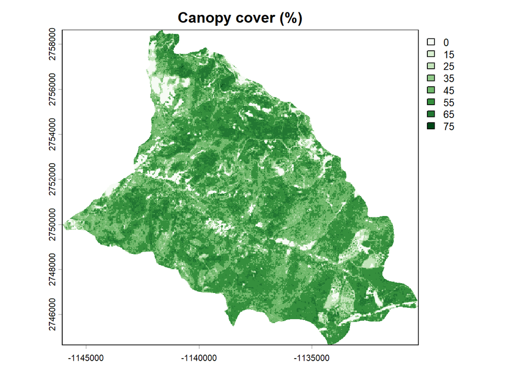

Forest canopy cover (%), LANDFIRE 2024 classes.

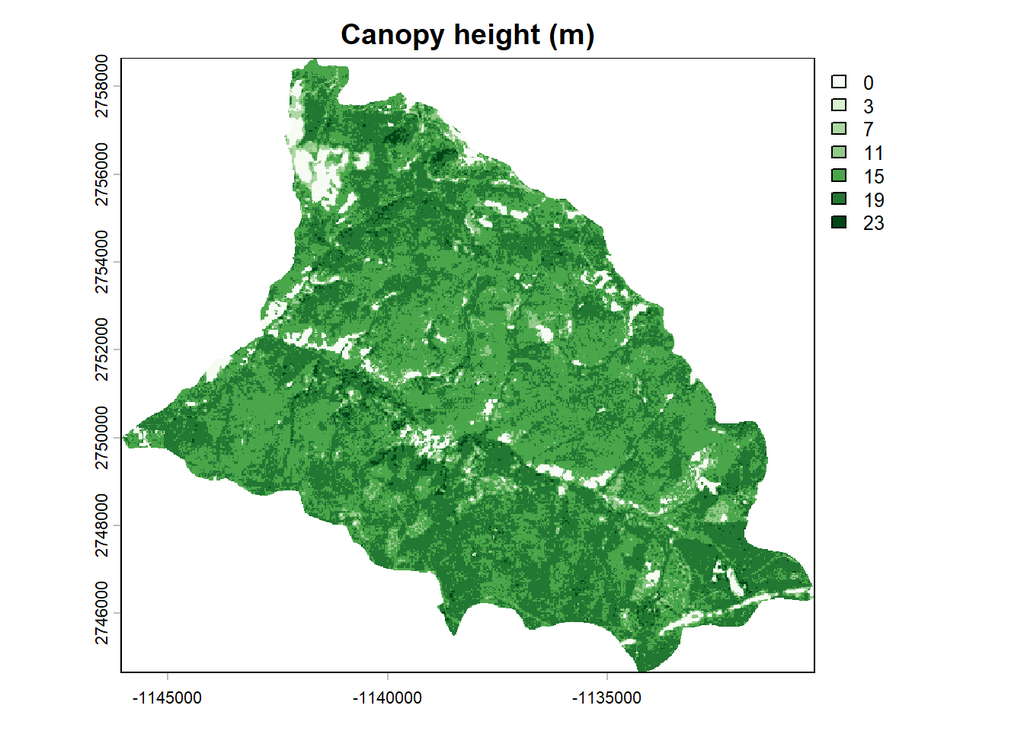

Forest canopy height (m), LANDFIRE 2024 classes.

## Disturbance history

LANDFIRE Annual Disturbance, 1999 to 2025. Each year’s codes are translated with that year’s LANDFIRE attribute table and grouped by type (`2_protocol/dist_type_groups.csv`). Year maps show the most recent year of each disturbance group; blank areas had no disturbance of that group. LANDFIRE may under-record insect mortality, which develops gradually; see the decision log. LANDFIRE’s own disturbance type and severity labels, with the group and severity class assigned to each, are listed in 4_product/data/disturbance_codes_100301030801.csv.

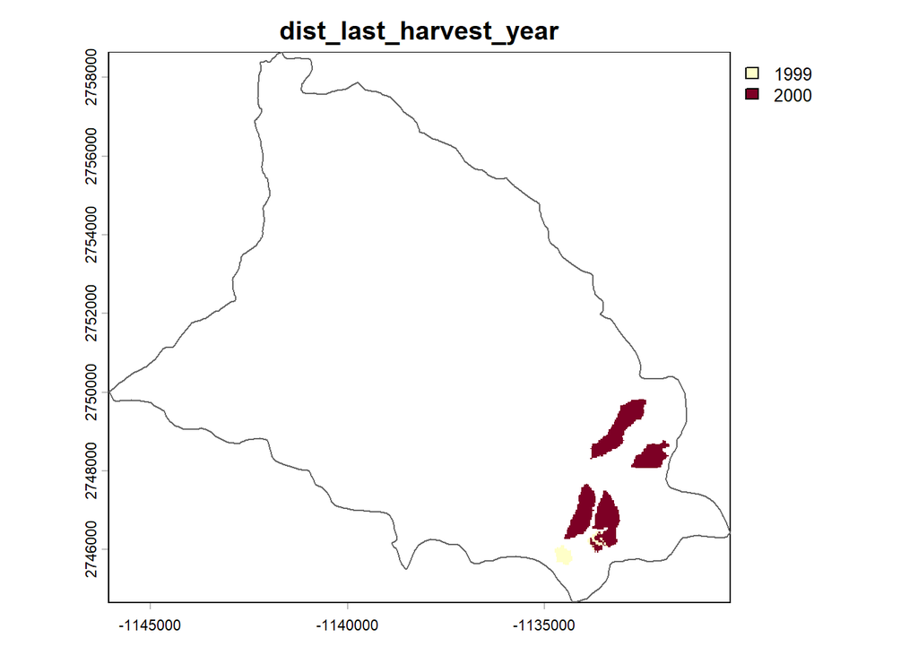

Most recent year of harvest, fire, and insect or disease disturbance.

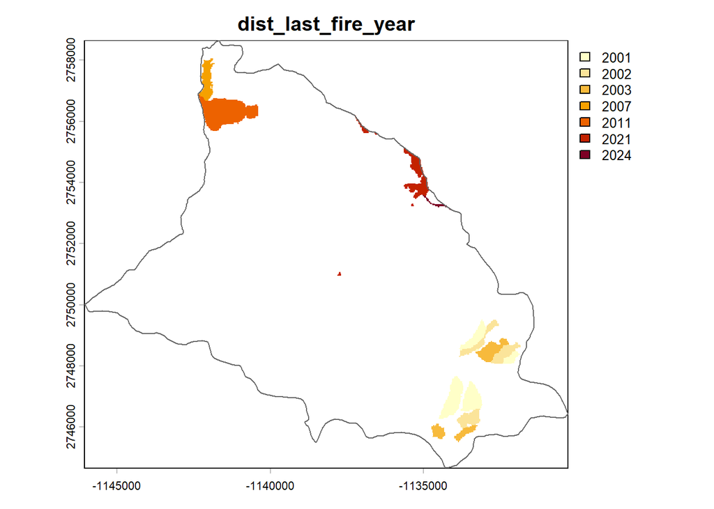

Most recent year of harvest, fire, and insect or disease disturbance.

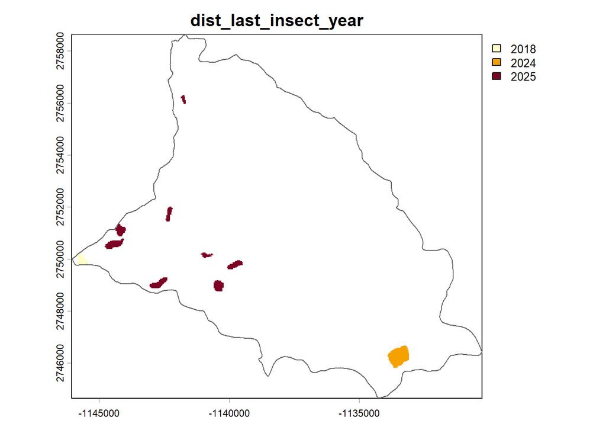

Most recent year of harvest, fire, and insect or disease disturbance.

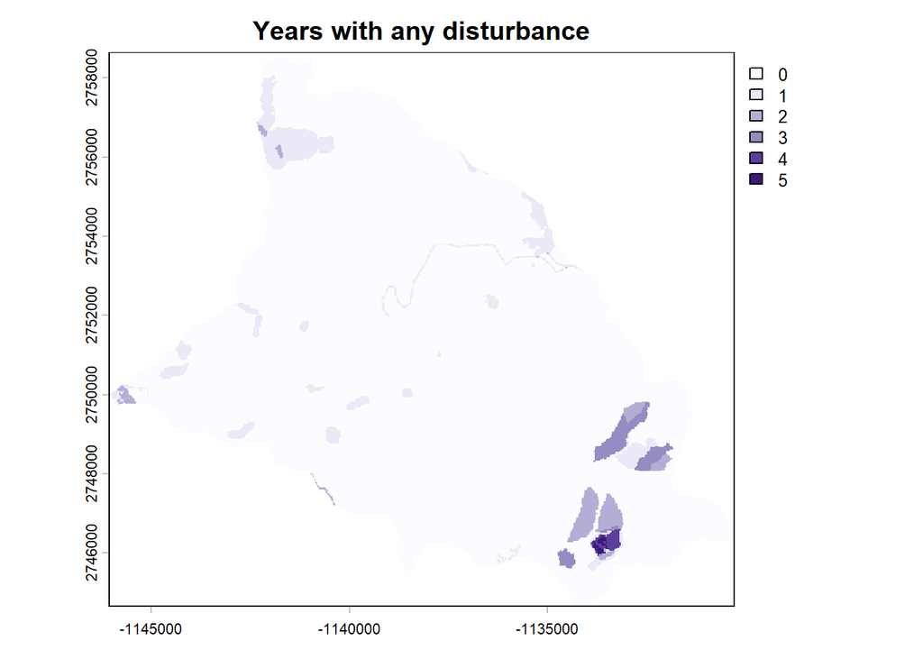

Number of years with any recorded disturbance.

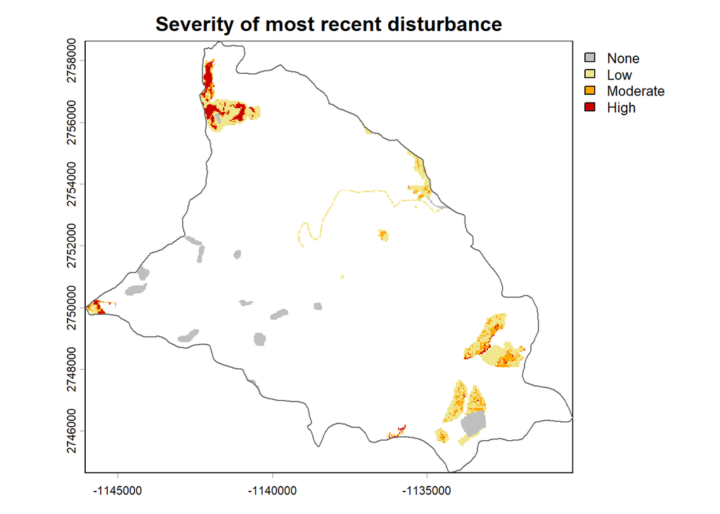

Severity class of the most recent disturbance (0 no severity class, 1 low, 2 medium or moderate, 3 high).

## Roads

National Forest System roads from the USFS road database (EDW), clipped to the watershed. County, state, and private roads are not included. Road length attributes describe whole road segments, not the clipped pieces.

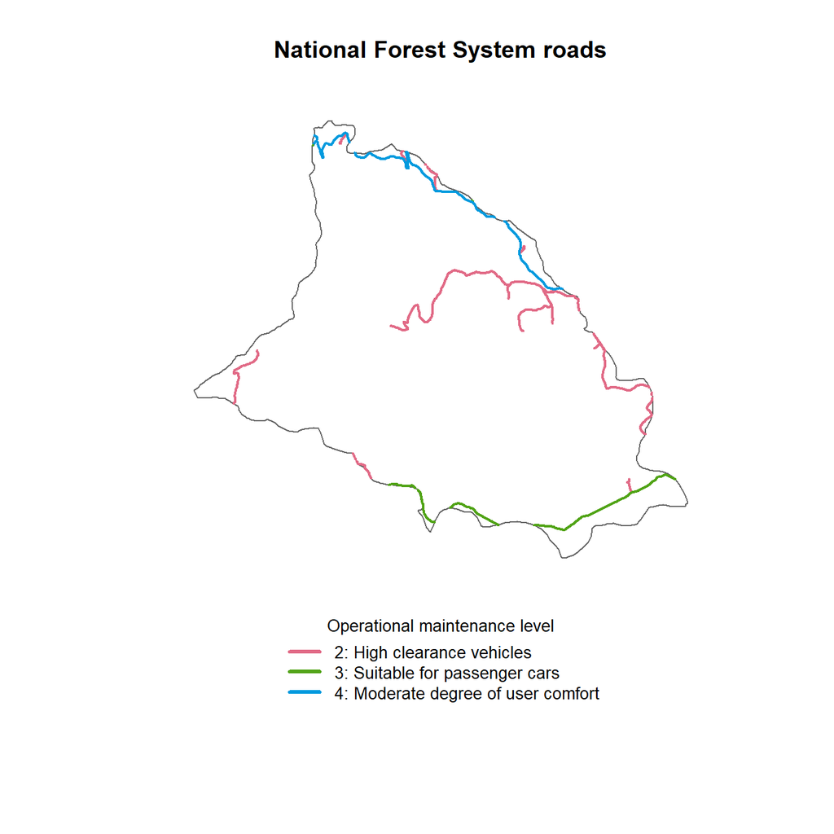

National Forest System roads by operational maintenance level.

## Quality checks

| Check | Result | Status |
| --- | --- | --- |
| All layers use the output CRS | 5070 | PASS |
| DEM cell size matches config | 10 x 10 | PASS |
| DEM grid snapped to cell size | xmin -1146060 / ymin 2744660 | PASS |
| Soil rasters on the same grid as the DEM | TRUE | PASS |
| No missing DEM cells inside watershed | 0 of 1057259 cells | PASS |
| DEM elevations within the range of the lower 48 states (-100 to 4500 m) | 1646.7 to 2425.8 | PASS |
| All streams fall within the watershed | 135 of 135 | PASS |
| Stream elevations within 50 m of DEM range | streams 1617.5 to 2327.3; DEM 1646.7 to 2425.8 | PASS |
| K-factors in SSURGO range (0.02 to 0.69) | 0.05 to 0.37 | PASS |
| No cells inside the watershed without soil data | 0 of 1057259 cells | PASS |
| Whole-soil K missing only where the map unit is entirely rock, rubble, pits, or water | 0 cells with missing K in map units that have soil | PASS |
| Share of watershed that is entirely rock, rubble, pits, or water (information) | 42 of 1057259 cells (0%) | INFO |
| Precipitation rasters on the same grid as the DEM | TRUE | PASS |
| Precipitation at watershed center within 1 mm/hr of NOAA point table | grid 23.99, 14.33, 4.6; NOAA 24, 14, 5 (mm/hr) | PASS |
| Shorter storms more intense than longer storms in every cell | TRUE | PASS |
| Forest rasters on the same grid as the DEM | TRUE | PASS |
| Forest values are LANDFIRE classes, not blended (20 or fewer distinct values per layer) | forest_cc: 8 values; forest_ch: 7 values | PASS |
| Disturbance rasters on the same grid as the DEM | TRUE | PASS |
| Disturbance years within the requested range | 1999 to 2025 (requested 1999 to 2025) | PASS |
| Disturbance count no greater than the number of years requested | max 5 of 27 years | PASS |
| Disturbance severity values are 0, 1, 2, or 3 | 0, 1, 2, 3 | PASS |
| All LANDFIRE disturbance types are in dist_type_groups.csv | all mapped | PASS |
| All roads fall within the watershed | 22 of 22 | PASS |
| National Forest System road length and density (information) | 45.5 km; 0.43 km per km² | INFO |

Checks marked CHECK are not necessarily errors; see the decision log for known differences (for example, stream attributes describe whole flowlines, not the clipped segments). Rows marked INFO describe the watershed rather than test the data.

## Soil map units

| Map unit key | K whole soil | K fine earth | % without K |
| --- | --- | --- | --- |
| 2393216 | 0.189 | 0.370 | 5 |
| 2441169 | 0.143 | 0.270 | 12 |
| 2484154 | 0.110 | 0.242 | 0 |
| 2484156 | 0.094 | 0.221 | 5 |
| 2484157 | 0.111 | 0.229 | 10 |
| 2484158 | 0.112 | 0.231 | 12 |
| 2484161 | 0.165 | 0.352 | 15 |
| 2484163 | 0.177 | 0.358 | 2 |
| 2484354 | 0.284 | 0.326 | 5 |
| 2486289 | NA | NA | 100 |
| 2497922 | 0.091 | 0.177 | 5 |
| 2512869 | 0.221 | 0.253 | 5 |
| 2512872 | 0.219 | 0.271 | 2 |
| 2512874 | 0.143 | 0.241 | 4 |
| 2512887 | 0.204 | 0.286 | 0 |
| 2604430 | 0.064 | 0.176 | 65 |
| 2604431 | 0.179 | 0.304 | 3 |
| 2604433 | 0.200 | 0.270 | 0 |
| 2604434 | 0.096 | 0.210 | 35 |
| 2604435 | 0.109 | 0.233 | 15 |
| 2604436 | 0.187 | 0.279 | 2 |
| 2604489 | 0.196 | 0.301 | 10 |
| 2609831 | 0.050 | 0.150 | 55 |
| 2609837 | 0.150 | 0.280 | 55 |
| 2609843 | 0.205 | 0.273 | 2 |

## Layer catalog

| layer | source | version | retrieved | native_crs | output_crs | output_resolution | processing |
| --- | --- | --- | --- | --- | --- | --- | --- |
| watershed_boundary | USGS Watershed Boundary Dataset via nhdplusTools::get_huc() | WBD record load date 2024-08-15; nhdplusTools 1.5.2 | 2026-10-21 23:38:13 MDT | EPSG:4326 (WGS 84) | EPSG:5070 (NAD83 / Conus Albers) | NA | Reprojected to output CRS; attributes renamed and converted per crosswalk. |
| dem | USGS 3DEP 1/3 arc-second seamless DEM (current), read via GDAL /vsicurl/ | 3DEP current tiles: n47w111, n48w111, n47w112, n48w112; source dates 19520101 to 20221007 (range across all source projects in the tiles; see dem_tiles_100301030801.csv); vertical datum North American… | 2026-11-11 20:43:08 MST | EPSG:4269 (NAD83) | EPSG:5070 (NAD83 / Conus Albers) | 10 x 10 | Reprojected and resampled (bilinear) to common grid; masked to watershed; no pit or flat filling; elevations keep the source vertical datum (see version); NoData = -9999. |
| streams | USGS NHDPlus HR network flowlines via nhdplusTools::get_nhdphr(), queried in tiles | 135 flowlines from 4 tiles; nhdplusTools 1.5.2 | 2026-10-12 17:13:48 MDT | EPSG:4326 (WGS 84) | EPSG:5070 (NAD83 / Conus Albers) | NA | Reprojected to output CRS; clipped to watershed; attributes renamed and converted per crosswalk. |
| soils | NRCS SSURGO via Soil Data Access (soilDB::SDA_spatialQuery, SDA_query) | Survey MT632, version date 9/5/2026 2:51:43 PM; soilDB 2.9.2 | 2026-11-11 20:43:13 MST | EPSG:4326 (WGS 84) | EPSG:5070 (NAD83 / Conus Albers) | 10 x 10 | Component K from first horizon with a value; map unit K as component-percent weighted mean of components with K (kwfact and kffact separately); percent of map unit without K recorded; polygons rasteri… |
| precip | NOAA Atlas 14 precipitation frequency grids, partial duration series (PFDS) | NOAA Atlas 14 Volume 12 Version 2 (folder inw); 2-year ARI; durations 30m, 60m, 06h | 2026-11-11 21:44:33 MST | EPSG:4269 (NAD83) | EPSG:5070 (NAD83 / Conus Albers) | 10 x 10 | Grids read from original zips; NAD83 geographic assigned where the grid has no CRS; cropped to watershed + 2 km; depth (0.001 in) converted to intensity (mm/hr) using crosswalk factors; resampled (bil… |
| forest | LANDFIRE Product Service v2 via rlandfire::landfireAPIv2() | LF2024_CC, LF2024_CH; rlandfire 2.0.2 | 2026-10-14 21:17:09 MDT | EPSG:5070 (NAD83 / Conus Albers) | EPSG:5070 (NAD83 / Conus Albers) | 10 x 10 | LANDFIRE products requested in output CRS; canopy height converted from decimeters to meters; resampled from 30 m to common grid with nearest neighbor (classed values); masked to watershed; NoData = -… |
| disturbance | LANDFIRE Annual Disturbance (final) via rlandfire::landfireAPIv2(); attribute tables from landfire.gov | 1999-2025; products LF2001_Dist99, LF2001_Dist00, LF2001_Dist01, LF2001_Dist02, LF2001_Dist03, LF2001_Dist04, LF2001_Dist05, LF2001_Dist06, LF2001_Dist07, LF2008_Dist08, LF2010_Dist09, LF2010_Dist10, … | 2026-10-14 22:05:11 MDT | EPSG:5070 (NAD83 / Conus Albers) | EPSG:5070 (NAD83 / Conus Albers) | 10 x 10 | Annual codes translated with each year’s own LANDFIRE attribute table; LANDFIRE DIST_TYPE values grouped into harvest, fire, insect, and other per 2_protocol/dist_type_groups.csv; LANDFIRE SEVERITY la… |
| roads | USFS National Forest System Roads (EDW_RoadBasic_01 map service, layer 0) | EDW road data, updated daily from national forest databases; 22 segments touching the watershed | 2026-11-11 20:42:58 MST | EPSG:4269 (NAD83) | EPSG:5070 (NAD83 / Conus Albers) | NA | National Forest System roads only (no county, state, or private roads); reprojected to output CRS; clipped to watershed; attributes renamed and converted per crosswalk (GIS miles to km). road_length_k… |

## Data dictionary

| variable | layer | units | data_type | range | n_missing | processing |
| --- | --- | --- | --- | --- | --- | --- |
| wbd_load_date | watershed_boundary | date | Date | 2024-08-15 to 2024-08-15 | 0 | renamed from loaddate; converted to date |
| area_km2 | watershed_boundary | km2 | numeric | 105.73 to 105.73 | 0 | renamed from areasqkm |
| states | watershed_boundary |  | character | 1 distinct values | 0 |  |
| huc12 | watershed_boundary |  | character | 1 distinct values | 0 |  |
| watershed_name | watershed_boundary |  | character | 1 distinct values | 0 | renamed from name |
| downstream_huc12 | watershed_boundary |  | character | 1 distinct values | 0 | renamed from tohuc |
| feature_date | streams | date | Date | 2012-02-15 to 2012-02-15 | 0 | renamed from fdate; converted to date |
| stream_name | streams |  | character | 9 distinct values | 65 | renamed from gnis_name |
| length_km | streams | km | numeric | 0.019 to 2.539 | 0 | renamed from lengthkm |
| reach_code | streams |  | character | 72 distinct values | 0 | renamed from reachcode |
| feature_code | streams |  | integer | 46003 to 55800 | 0 | renamed from fcode |
| nhdplus_id | streams |  | numeric | 2.30013e+13 to 2.30013e+13 | 0 | renamed from nhdplusid |
| stream_order | streams |  | integer | 1 to 4 | 0 | renamed from streamorde |
| hydro_seq | streams |  | numeric | 2.30013e+13 to 2.30013e+13 | 0 | renamed from hydroseq |
| downstream_hydro_seq | streams |  | numeric | 2.30013e+13 to 2.30013e+13 | 0 | renamed from dnhydroseq |
| drainage_area_km2 | streams | km2 | numeric | 0.2317 to 107.201 | 0 | renamed from totdasqkm |
| elev_max_m | streams | m | numeric | 1648 to 2327.33 | 0 | renamed from maxelevsmo; source NoData -9998 set to NA; multiplied by 0.01 (cm to m) |
| elev_min_m | streams | m | numeric | 1617.54 to 2227.05 | 0 | renamed from minelevsmo; source NoData -9998 set to NA; multiplied by 0.01 (cm to m) |
| slope_m_per_m | streams | m/m | numeric | 0.00867925 to 0.2858442 | 0 | renamed from slope; source NoData -9998 set to NA |
| elevation_m | dem | m | numeric (raster) | 1646.75 to 2425.75 | NA | derived from elevation (band 1); source NoData -9999 set to NA |
| soil_kw | soil_kw | K-factor (US customary) | numeric (raster) | 0.05 to 0.283684 | NA | derived from kwfact |
| soil_kf | soil_kf | K-factor (US customary) | numeric (raster) | 0.15 to 0.37 | NA | derived from kffact |
| soil_pct_no_k | soil_pct_no_k | % | numeric (raster) | 0 to 100 | NA | derived from comppct_r |
| precip_2yr_30m | precip_2yr_30m | mm/hr | numeric (raster) | 23.5712 to 24.4324 | NA | derived from 2yr30ma.zip grid; multiplied by 0.0508 (0.001 in (depth) to mm/hr) |
| precip_2yr_60m | precip_2yr_60m | mm/hr | numeric (raster) | 14.0716 to 14.5989 | NA | derived from 2yr60ma.zip grid; multiplied by 0.0254 (0.001 in (depth) to mm/hr) |
| precip_2yr_06h | precip_2yr_06h | mm/hr | numeric (raster) | 4.43167 to 4.7841 | NA | derived from 2yr06ha.zip grid; multiplied by 0.004233333 (0.001 in (depth) to mm/hr) |
| forest_cc | forest_cc | % | numeric (raster) | 0 to 75 | NA | derived from CC |
| forest_ch | forest_ch | m | numeric (raster) | 0 to 23 | NA | derived from CH; multiplied by 0.1 (0.1 m to m) |
| dist_last_harvest_year | dist_last_harvest_year | year | numeric (raster) | 1999 to 2000 | NA | derived from LANDFIRE annual disturbance codes |
| dist_last_fire_year | dist_last_fire_year | year | numeric (raster) | 2001 to 2024 | NA | derived from LANDFIRE annual disturbance codes |
| dist_last_insect_year | dist_last_insect_year | year | numeric (raster) | 2018 to 2025 | NA | derived from LANDFIRE annual disturbance codes |
| dist_count | dist_count |  | numeric (raster) | 0 to 5 | NA | derived from LANDFIRE annual disturbance codes |
| dist_last_severity | dist_last_severity |  | numeric (raster) | 0 to 3 | NA | derived from LANDFIRE annual disturbance codes |
| road_id | roads |  | character | 22 distinct values | 0 | renamed from id |
| road_name | roads |  | character | 22 distinct values | 0 | renamed from name |
| road_length_km | roads | km | numeric | 0.03862426 to 43.92222 | 0 | renamed from gis_miles; multiplied by 1.609344 (miles to km) |
| jurisdiction | roads |  | character | 1 distinct values | 0 |  |
| route_status | roads |  | character | 1 distinct values | 0 |  |
| maint_level_operational | roads |  | character | 3 distinct values | 0 | renamed from oper_maint_level |
| maint_level_objective | roads |  | character | 4 distinct values | 0 | renamed from objective_maint_level |
| functional_class | roads |  | character | 2 distinct values | 0 |  |
| surface_type | roads |  | character | 3 distinct values | 0 |  |
| open_for_use_to | roads |  | character | 1 distinct values | 0 | renamed from openforuseto |